# Flurex Compositional Analysis

# 1 GMH ASV ANALYSIS PIPELINE

This Rmarkdown contains the commands necessary to perform initial differential abundance analyses of the output from the DF_GMH_PIPELINE There will be things that should be updated to fit the exact project. It is important that metadata is loaded correctly and it should contain a variable identifying negative controls and mock samples. I recommend visiting the [“Analysis of community ecology data in R”](https://www.davidzeleny.net/anadat-r/doku.php/en:start) to read about the theory behind the alpha and beta diversity and examples of the necessary R-code to execute them. For analyses of differential abundance I will use the DAtest package [(Russel et al., 2018)](https://www.biorxiv.org/content/10.1101/241802v1). Another excellent source of help is the R [cheat-sheets](https://www.rstudio.com/resources/cheatsheets/).

# 2 INFO

This document has been fitted to perform beta diversity calculations of phyloseq element from the Import & QC script. It has been fitted for data from Flurex (internal project name: R20-22). The project data contains 16S V3 amplicon sequencing from feces samples from 4 different days and cecum and ileum samples from one day from 48 rats. There are feces samples from all rats from day 0, 2, 4 and 8. Cecum and ileum samples were all collected at dissection on day 8. Please read the method section for this paper for details on experimental setup.

Metadata contains sample information regarding: - rat number/name, cage number (rats were co-caged 2-2), day of sampling, material (feces, cecum, ileum), sequencing information (gram of material used for extracted DNA, DNA concentrations, primers, barcodes for demultiplexing, batch number (“run” = c2, c3, c4)), treatment groups. Several columns have been created for easy sample grouping during analysis, including for distinguishing between vancomycin and PFOS treatment alone.

Metadata contains results from: - Bodyweight per sampling day, while cecum and liver weight for day 8 (addition column with organ weights normalised to bodyweight).

- PFOS quantification of:
  - Blood serum from day 4 and 8 measured in µg/mL
  - Liver tissue from day 8 measured in mg PFOS in full liver weight
- Short-chain fatty acids quantification of 10 compounds in colonic water given in mM from day 8: acetic acid, formic acid, propanoic acid, 2methyl-propanoic acid, butanoic acid, 3methyl-butanoic acid, pentanoic acid, 4methyl-pentanoic acid, hexanoic acid and heptanoic acid

```r
knitr::opts_chunk$set(echo = TRUE)

# Load libraries
library(tidyverse)
library(phyloseq)
library(decontam)
library(pals)
library(ggpubr)
library(rstatix)
library(vegan)
library(reshape2)
library(DAtest)
library(ape)
library(kableExtra)
library(magick)
library(forcats)

# Create used folders if missing
if (!file.exists("R_objects")) dir.create(file.path(getwd(), "R_objects"))
if (!file.exists("plots")) dir.create(file.path(getwd(), "plots"))
if (!file.exists("plots/relabu")) dir.create(file.path(getwd(), "plots/relabu"))
if (!file.exists("plots/difabu")) dir.create(file.path(getwd(), "plots/difabu"))
if (!file.exists("tables")) dir.create(file.path(getwd(), "tables"))
if (!file.exists("scripts")) dir.create(file.path(getwd(), "scripts"))

saveRDS(params, "R_objects/comp_params.RDS")
```

## 2.1 SCRIPTS

This section contains the scripts for the custom functions used in this pipeline

### 2.1.1 FILTER TAXA

These functions are used to merge ASV that are not one of the most abundant, or below a defined threshold, into “Other”

```r
# This function merges anything not in the top (10 by default) most abundant ASVs
merge_less_than_top <- function(pobject, top=10){
  # transform to sample counts to relative values
  transformed <- transform_sample_counts(pobject, function(x) x/sum(x))

    # Orientate and export otu table
  if (taxa_are_rows(transformed)) otu.table <- as.data.frame(otu_table(transformed)) else otu.table <- as.data.frame(t(otu_table(transformed)))

  # sort otu table by decreasing abundance
  otu.sort <- otu.table[order(rowMeans(otu.table), decreasing = TRUE),]

  # Create list of ASVs to merge
  otu.list <- row.names(otu.sort[(top+1):nrow(otu.sort),])
  if(any("Others" %in% rownames(otu.table))) otu.list <- c(otu.list,"Others")

  # perform the merger with the original sample counts
  merged <- merge_taxa(pobject, otu.list, 1)

  # change the taxa name
  taxa_names(merged)[taxa_names(merged) %in% otu.list[1]] <- "Others"

  # change taxa to "Other" for all levels not being NAs
  for (i in 1:ncol(tax_table(merged))){
    if (sum(!is.na(tax_table(merged)[,i]))){
      tax_table(merged)["Others",i] <- "Others"
    }
  }
  return(merged)
}

# This function merges ASVs that are below a defined ratio, with the default being 0.001 (0.1%)
merge_low_abundance <- function(pobject, threshold=0.001){

  # transform to sample counts to relative values
  transformed <- transform_sample_counts(pobject, function(x) x/sum(x))

  # Orientate and export otu table
  if (taxa_are_rows(transformed)) otu.table <- as.data.frame(otu_table(transformed)) else otu.table <- as.data.frame(t(otu_table(transformed)))

  # Create list of ASVs to merge
  otu.list <- row.names(otu.table[rowMeans(otu.table) < threshold,])
  if(any("Others" %in% rownames(otu.table))) otu.list <- c(otu.list,"Others")

  # perform the merger with the original sample counts
  merged <- merge_taxa(pobject, otu.list, 1)

  # change the taxa name
  taxa_names(merged)[taxa_names(merged) %in% otu.list[1]] <- "Others"

  # change taxa to "Other" for all levels not being NAs
  for (i in 1:ncol(tax_table(merged))){
    if (sum(!is.na(tax_table(merged)[,i]))){
      tax_table(merged)["Others",i] <- "Others"
    }
  }
  return(merged)
}

merge_prevalence <- function(pobject, variable, min.samples){
  # transform to sample counts to relative values
  if (taxa_are_rows(transformed)) otu.table <- as.data.frame(otu_table(transformed)) else otu.table <- as.data.frame(t(otu_table(transformed)))

  # make binary
  otu.table[otu.table != 0] <- 1

  # extract metadata
  dat <- data.frame(sample_data(pobject))

  # set groups
  vgroup <- unique(dat[,variable])

  # create count table
  counts <- data.frame(row.names = row.names(otu.table))
  for (i in seq(length(vgroup))) counts[,vgroup[i]] <- rowSums(otu.table[,dat[,variable]==vgroup[i]])

  counts$keep <- ifelse(rowSums(counts) > min.sample*length(vgroup), TRUE, FALSE)

  # Create list of ASVs to merge
  otu.list <- row.names(counts[!counts$keep,])
  if(any("Others" %in% rownames(otu.table))) otu.list <- c(otu.list,"Others")

  # perform the merger with the original sample counts
  merged <- merge_taxa(pobject, otu.list, 1)

  # change the taxa name
  taxa_names(merged)[taxa_names(merged) %in% otu.list[1]] <- "Others"

  # change taxa to "Other" for all levels not being NAs
  for (i in 1:ncol(tax_table(merged))){
    if (sum(!is.na(tax_table(merged)[,i]))){
      tax_table(merged)["Others",i] <- "Others"
    }
  }
  return(merged)

}
# save functions
save(merge_less_than_top, merge_low_abundance, file = "scripts/merge_abundance.Rdata")

# clear the environment and release memory
rm(list = ls(all.names = TRUE)) #will clear all objects includes hidden objects.
invisible(gc()) #free up memory and report the memory usage.
```

# 3 DIFFERENTIAL ABUNDANCE

Analyses below are used for investigation of differential abundance between groupings of samples with the main focus of PFOS-driven differential abundance on day 8 (highest PFOS exposure).

# 4 ANALYSES USED

## 4.1 FECES DAY 8 BY TREATMENT - DIFFERENTIAL ABUNDANCE

There are many different methods that can be used to calculate differential abundance, all with their own advantages and disadvantages. Which method to use depends on the data and therefore I will be using DAtest [@DAtest] as described by [Russel et al. (2018)](https://doi.org/10.1101/241802).

This analysis shows all taxa differing significantly between treatment groups on day 8. This will illustrate mainly differences driven by vancomycin treatment. PFOS driven effects will be explored by subset analyses below.

### 4.1.1 GENUS

#### 4.1.1.1 SET PARAMETERS

```r
params <- readRDS("R_objects/comp_params.RDS")

LVL <- "Genus"
MTRL <- "Feces"
DAY <- "d8"
VAN <- "all"
PDI <- "treatment"
SUBNAME <- "Feces_d8"
load(paste0("R_objects/Agglomerated_",SUBNAME,".RData"))

# Create sub-folder
  if (!file.exists(paste0("plots/difabu/",SUBNAME))) dir.create(file.path(getwd(), paste0("plots/difabu/",SUBNAME)))

# Filter data
filt <- preDA(data = phy.ge, min.reads = 20, min.samples = 4)
```

```
## 80 features grouped as 'Others' in the output
```

#### 4.1.1.2 TEST METHOD

```r
# Test best method
filt.test <- testDA(filt, predictor = PDI, effectSize = 10) # TIME AND COMPUTAIONALLY DEMANDING STEP

# Evaluate the plot and summary table
sum.fil <- summary(filt.test)
write.csv(sum.fil, file = paste0("plots/difabu/",SUBNAME,"/filtersummary_",MTRL,"_",DAY,"_",VAN,"_",PDI,"_",LVL,".csv"))
p.fil <- plot(filt.test)
p.fil
pdf(paste0("plots/difabu/",SUBNAME,"/filterplot_",MTRL,"_",DAY,"_",VAN,"_",PDI,"_",LVL,".pdf"))
    p.fil
    dev.off()
```

[output not shown]

#### 4.1.1.3 RUN DAtest

Having now identified ANOVA (DA.aoa) as the optimal test for all four treatment groups I will use it to calculate differential abundance.

```r
# Run the selected analysis
filt.DA <- DA.aoa(filt, predictor = PDI)

# Evaluate the plot and summary table
table(filt.DA$pval.adj < 0.05)
```

```
##
## FALSE  TRUE
##    30    63
```

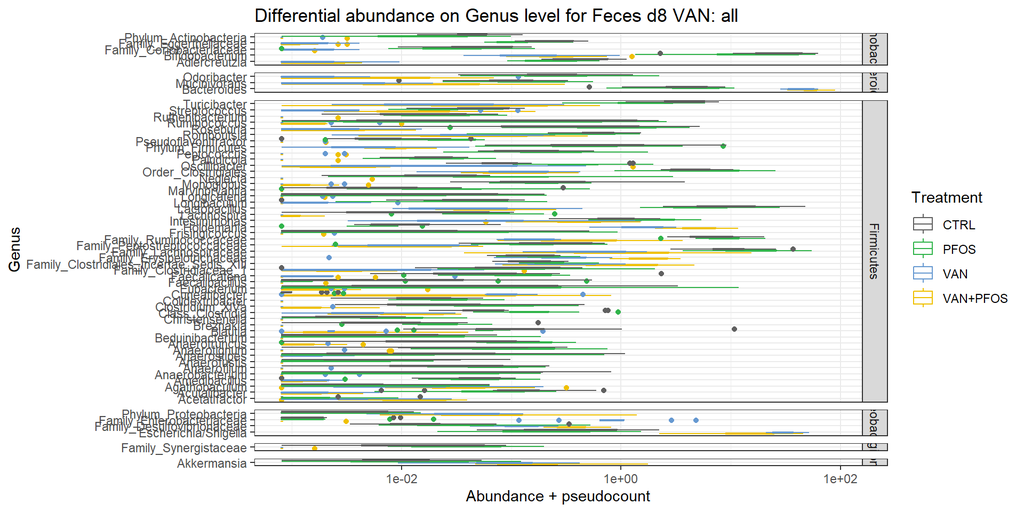

```r
filt.p5 <- filt.DA[filt.DA$pval.adj < 0.05,]
write.csv(filt.p5,paste0("plots/difabu/",SUBNAME,"/stats_",MTRL,"_",DAY,"_",VAN,"_",PDI,"_",LVL,".csv"))

# Create a subset of the samples
filt.ra <- transform_sample_counts(filt, function(x) x/sum(x)*100)
DA.sig <- prune_taxa(filt.DA$Feature[filt.DA$pval.adj < 0.05], x = filt.ra)

# melt the data
DAm <- psmelt(DA.sig)
# Create plot
pseudocount <- min(DAm$Abundance[DAm$Abundance != 0])
p.dif <- ggplot(DAm, aes(x = Genus, y = Abundance+pseudocount, color = fct_rev(treatment))) + geom_boxplot() + scale_y_log10() + coord_flip() + scale_color_manual(values = params$COL, breaks=c("CTRL","PFOS","VAN","VAN+PFOS")) + facet_grid(Phylum ~ . , scales = "free_y", space = "free") + theme_bw() + labs(color = "Treatment")
p.dT <- p.dif + ggtitle(paste0("Differential abundance on ",LVL," level for ",MTRL," ",DAY," VAN: ",VAN))
p.dT
```

```r
suppressMessages(ggsave(paste0("plots/difabu/",SUBNAME,"/diffplot_",SUBNAME,"_",PDI,"_",LVL,".pdf"), p.dif, device = "pdf", units = "mm", width = 200, height = 400, dpi = 300))
suppressMessages(ggsave(paste0("plots/difabu/",SUBNAME,"/diffplot_",SUBNAME,"_",PDI,"_",LVL,".png"), p.dif, device = "png", units = "mm", width = 200, height = 400, dpi = 300))

# clear the environment and release memory
rm(list = ls(all.names = TRUE))
invisible(gc())
```

### 4.1.2 FAMILY

#### 4.1.2.1 RUN DAtest

```r
params <- readRDS("R_objects/comp_params.RDS")

LVL <- "Family"
MTRL <- "Feces"
DAY <- "d8"
VAN <- "all"
PDI <- "treatment"
SUBNAME <- "Feces_d8"
load(paste0("R_objects/Agglomerated_",SUBNAME,".RData"))

# Create sub-folder
  if (!file.exists(paste0("plots/difabu/",SUBNAME))) dir.create(file.path(getwd(), paste0("plots/difabu/",SUBNAME)))

# Filter data
filt <- preDA(data = phy.fa, min.reads = 20, min.samples = 4)
```

```
## 35 features grouped as 'Others' in the output
```

```r
# Run the selected analysis
filt.DA <- DA.aoa(filt, predictor = PDI)

# Evaluate the plot and summary table
table(filt.DA$pval.adj < 0.05)
```

```
##
## FALSE  TRUE
##    17    28
```

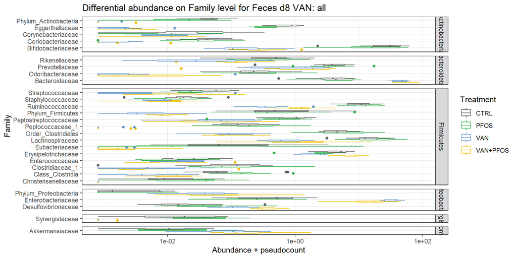

```r
filt.p5 <- filt.DA[filt.DA$pval.adj < 0.05,]
write.csv(filt.p5,paste0("plots/difabu/",SUBNAME,"/stats_",MTRL,"_",DAY,"_",VAN,"_",PDI,"_",LVL,".csv"))

# Create a subset of the samples
filt.ra <- transform_sample_counts(filt, function(x) x/sum(x)*100)
DA.sig <- prune_taxa(filt.DA$Feature[filt.DA$pval.adj < 0.05], x = filt.ra)

# melt the data
DAm <- psmelt(DA.sig)
# Create plot
pseudocount <- min(DAm$Abundance[DAm$Abundance != 0])
p.dif <- ggplot(DAm, aes(x = Family, y = Abundance+pseudocount, color = fct_rev(treatment))) + geom_boxplot() + scale_y_log10() + coord_flip() + scale_color_manual(values = params$COL, breaks=c("CTRL","PFOS","VAN","VAN+PFOS")) + facet_grid(Phylum ~ . , scales = "free_y", space = "free") + theme_bw() + labs(color = "Treatment")

p.dT <- p.dif + ggtitle(paste0("Differential abundance on ",LVL," level for ",MTRL," ",DAY," VAN: ",VAN))
p.dT
```

```r
suppressMessages(ggsave(paste0("plots/difabu/",SUBNAME,"/diffplot_",SUBNAME,"_",PDI,"_",LVL,".pdf"), p.dif, device = "pdf", units = "mm", width = 350, height = 200, dpi = 300))
suppressMessages(ggsave(paste0("plots/difabu/",SUBNAME,"/diffplot_",SUBNAME,"_",PDI,"_",LVL,".png"), p.dif, device = "png", units = "mm", width = 350, height = 200, dpi = 300))

# clear the environment and release memory
rm(list = ls(all.names = TRUE))
invisible(gc())
```

## 4.2 CONCLUSION

Multiple taxa are significantly differing between treatment groups on day 8, which is expected from the large impact on gram-positive bacteria from vancomycin treatment. Below we will explore the specific PFOS-driven effects on family and genus level.